# Describe trends in your data

Author

Affiliation

Daniela Palleschi

Humboldt-Universität zu Berlin

Published

April 13, 2023

```r
knitr::opts_chunk$set(eval = T, # evaluate chunks
                      echo = T, # 'print code chunk?'
                      message = F, # 'print messages (e.g., warnings)?'
                      error = F, # stop when error encountered
                      warning = F) # don't print warnings
```

```r
# Create references.json file based on the citations in this script
# make sure you have 'bibliography: references.json' in the YAML
# rbbt::bbt_update_bib("_data_communication.qmd")
```

# 1 Load in dataset

```r
# load tidyverse
library(tidyverse)

# load data
df_lifetime <- readr::read_csv(here::here("data/tidy_data_lifetime_pilot.csv"),
                               # for special characters
                               locale = readr::locale(encoding = "latin1")
                               ) |>
  mutate_if(is.character,as.factor) |> # all character variables as factor
  filter(type == "critical", # only critical trials
         px != "px3", # this participant had lots of 0's for some reason
         region=="verb")
```

# 2 Data description

- number of participants
- number of observations
- number of trials

Data was collected from 7 participants. Data was collected from native speakers of English (*n* = 7, female = 7).

# 3 Descriptive statistics

## 3.1 mean, standard deviation

- `mean(x)`: mean of x
- `sd(x)`: standard deviation of x
- `round(x,3)`: round x to 3 decimal points

```r
mean_ff <- mean(df_lifetime$ff)
sd_ff <- sd(df_lifetime$ff)
```

The mean first-fixation time at the critical verb region was 193.4 milliseconds (ms), and the standard deviation was 65.7 ms.

### 3.1.1 Main effect of lifetime (dead vs. living)

Table with summmary statistics for first-fixation duration at the verb region

| lifetime | N | mean.ff | sd |
| --- | --- | --- | --- |
| dead | 279 | 196.7 | 63.0 |
| living | 280 | 190.1 | 68.2 |

The living condition elicited similar, but slightly shorter, first fixation times (mean = 190.1, sd = 68.2) than the dead condition (mean = 196.7, sd = 63) conditions.

### 3.1.2 Main effect of tense (PP vs. SF)

Table with summmary statistics for first-fixation duration at the verb region

| tense | N | mean.ff | sd |
| --- | --- | --- | --- |
| PP | 280 | 196.5 | 68.2 |
| SF | 279 | 190.3 | 63.0 |

The Simple Future condition (mean = 190.3, sd = 63) elicited similar, but slightly shorter, first fixation times than the Present Perfect condition (mean = 196.5, sd = 68.2).

### 3.1.3 Nested effects (lifetime within each level of tense)

```r
summary_ff <- df_lifetime |>
  filter(region=="verb") |>
  group_by(condition,lifetime,tense) %>%
  summarise(N = n(),
            mean.ff = mean(ff, na.rm = T),
            sd = sd(ff, na.rm = T))

knitr::kable(summary_ff, digits=1,
             caption = "Table with summmary statistics for first-fixation duration at the verb region")
```

Table with summmary statistics for first-fixation duration at the verb region

| condition | lifetime | tense | N | mean.ff | sd |
| --- | --- | --- | --- | --- | --- |
| deadPP | dead | PP | 140 | 198.9 | 57.9 |
| deadSF | dead | SF | 139 | 194.6 | 67.9 |
| livingPP | living | PP | 140 | 194.2 | 77.3 |
| livingSF | living | SF | 140 | 186.0 | 57.6 |

In the present perfect condition, the dead (mean = 198.9, sd = 57.9) elicited longer reading times than the living (mean = 194.2, sd = 77.3) conditions.

Alternatively:

```r
deadPP_ff <- df_lifetime |>
  filter(region=="verb",
         condition=="deadPP") |>
  summarise(N = n(),
            mean.ff = mean(ff, na.rm = T),
            sd = sd(ff, na.rm = T))
```

198.8714286

- number of observations, number of participants
- printing tables
- in-line code

# 4 Describing plots

## 4.1 Main effect of lifetime

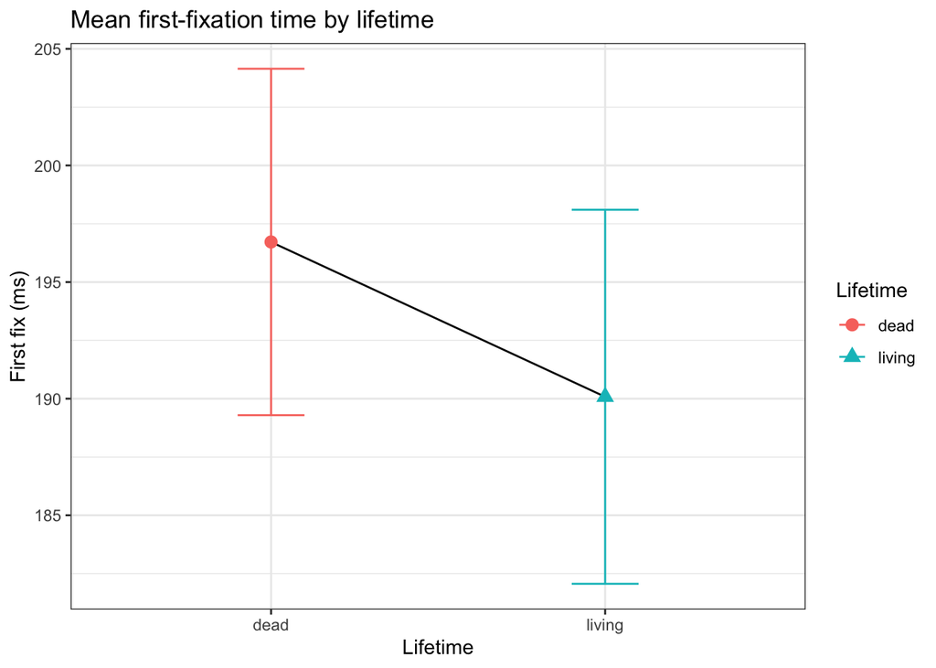

## 4.2 Main effect of tense

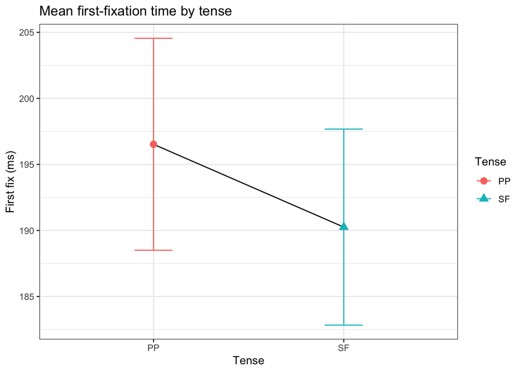

## 4.3 Nested effects

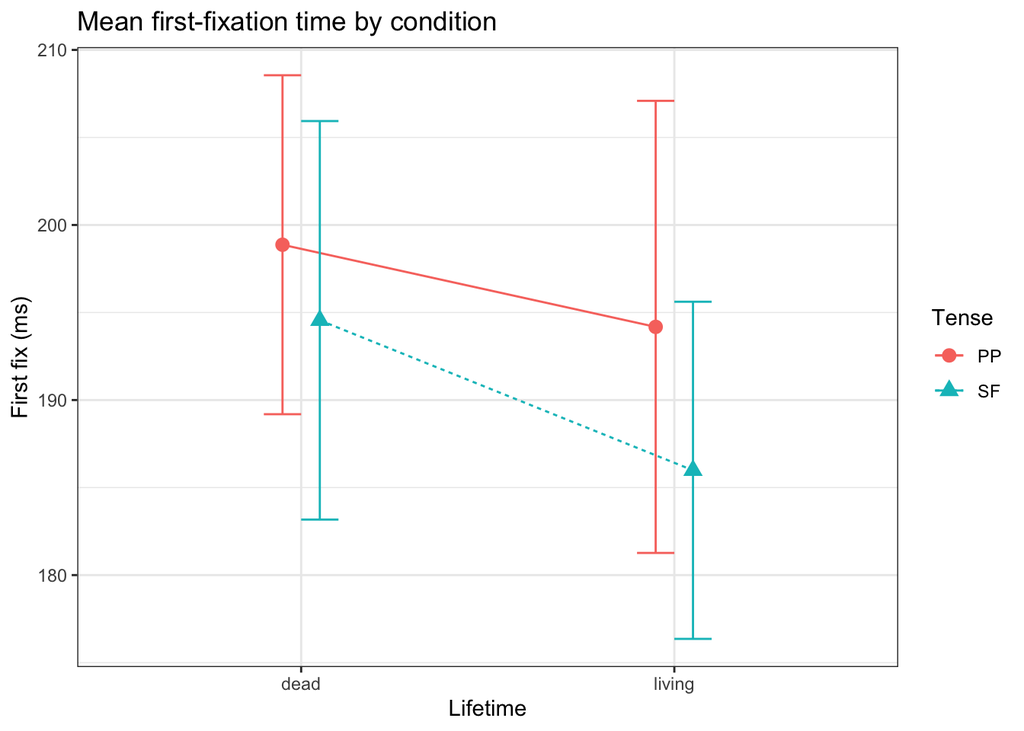

```r
df_lifetime |>
  filter(region == "verb") |>
  ggplot(aes(x = lifetime, y = ff,
                     shape = tense,
                     group = tense,
                     color = tense)) +
  labs(title="Mean first-fixation time by condition",
       x = "Lifetime",
       y = "First fix (ms)",
       shape = "Tense", group = "Tense", color = "Tense", linetype = "Tense") +
  stat_summary(fun = "mean", geom = "point", size = 3, position = position_dodge(0.2)) +
  stat_summary(fun = "mean", geom = "line", position = position_dodge(0.2), aes(linetype=tense)) +
  stat_summary(fun.data = "mean_cl_normal", geom = "errorbar", width = .2
               , position = position_dodge(0.2)) +
  theme_bw()
```

The figure shows the mean first fixation times for each condition.